# HW11_syQiu

Author

Shuyi Qiu

Set-up

```r
library(tidyverse)
theme_set(theme_light(base_family = "Optima"))

library(modelsummary)
library(broom)
library(gt)
library(performance)

library(gssr)
gss18 <- gss_get_yr(2018)

vars <- c(
  "hompop", "sibs", "numwomen", "nummen", "age", "sex", "race", "attend", "polviews", "degree",
  "happy", "sexornt", "premarsx", "condom", "wrkslf", "fefam", "cappun", "padeg", "madeg"
)

d <- gss18 |>
  select(all_of(vars)) |>
  haven::zap_missing() |>
  ## continuous vars
  mutate(across(all_of(vars[1:5]), haven::zap_labels)) |>
  ## categorical vars
  #mutate(across(!vars[1:5], haven::as_factor)) |>
  mutate(numtot = numwomen + nummen)
```

# 11.1 Goodness of Fit

## 11.1.1 Model Fit

```r
df <- d |>
  mutate(
    rba = ifelse(degree >= 3, T, F),
    sibs = as.numeric(sibs)
    ) |>
  select(rba, padeg, madeg, sibs) |>
  drop_na()

logit_mod1 <- glm(formula = rba ~ padeg + madeg + sibs, data = df, family = binomial(link = "logit"))

summary(logit_mod1)
```

```
Call:
glm(formula = rba ~ padeg + madeg + sibs, family = binomial(link = "logit"),
    data = df)

Deviance Residuals:
    Min       1Q   Median       3Q      Max
-1.9105  -0.8699  -0.6315   1.0308   2.5873

Coefficients:
            Estimate Std. Error z value Pr(>|z|)
(Intercept) -1.21125    0.12981  -9.331  < 2e-16 ***
padeg        0.39800    0.05212   7.636 2.23e-14 ***
madeg        0.31709    0.05782   5.484 4.16e-08 ***
sibs        -0.09991    0.02460  -4.061 4.88e-05 ***
---
Signif. codes:  0 '***' 0.001 '**' 0.01 '*' 0.05 '.' 0.1 ' ' 1

(Dispersion parameter for binomial family taken to be 1)

    Null deviance: 2147.2  on 1644  degrees of freedom
Residual deviance: 1889.1  on 1641  degrees of freedom
AIC: 1897.1

Number of Fisher Scoring iterations: 4
```

```r
performance_hosmer(logit_mod1)
```

```
# Hosmer-Lemeshow Goodness-of-Fit Test

  Chi-squared: 5.320
           df: 8
      p-value: 0.723
```

```
Summary: model seems to fit well.
```

The Hosmer-Lemeshow test compares the observed and predicted proportions within each group. Therefore, a large value of Chi-squared with small p-value shows that there is a significant gap between the observed value and predicted value, indicating a poor fit of the model. A low value of Chi-squared with a large p-value shows that the predicted value and observed value is very close, therefore the model is a good fit.

## 11.1.2 Link Test

```r
df$pred_rba = predict(logit_mod1)
logit_mod1_link = glm(formula = rba ~ pred_rba, data = df, family = binomial(link = "logit"))

summary(logit_mod1_link)
```

```
Call:
glm(formula = rba ~ pred_rba, family = binomial(link = "logit"),
    data = df)

Deviance Residuals:
    Min       1Q   Median       3Q      Max
-1.9105  -0.8699  -0.6315   1.0308   2.5873

Coefficients:
             Estimate Std. Error z value Pr(>|z|)
(Intercept) 1.769e-09  6.675e-02    0.00        1
pred_rba    1.000e+00  6.839e-02   14.62   <2e-16 ***
---
Signif. codes:  0 '***' 0.001 '**' 0.01 '*' 0.05 '.' 0.1 ' ' 1

(Dispersion parameter for binomial family taken to be 1)

    Null deviance: 2147.2  on 1644  degrees of freedom
Residual deviance: 1889.1  on 1643  degrees of freedom
AIC: 1893.1

Number of Fisher Scoring iterations: 3
```

The $\beta$ coefficient is 1. It means that the model is a good fit.

# 11.2 Poisson Regression

## 11.2.1 Regression & Plot

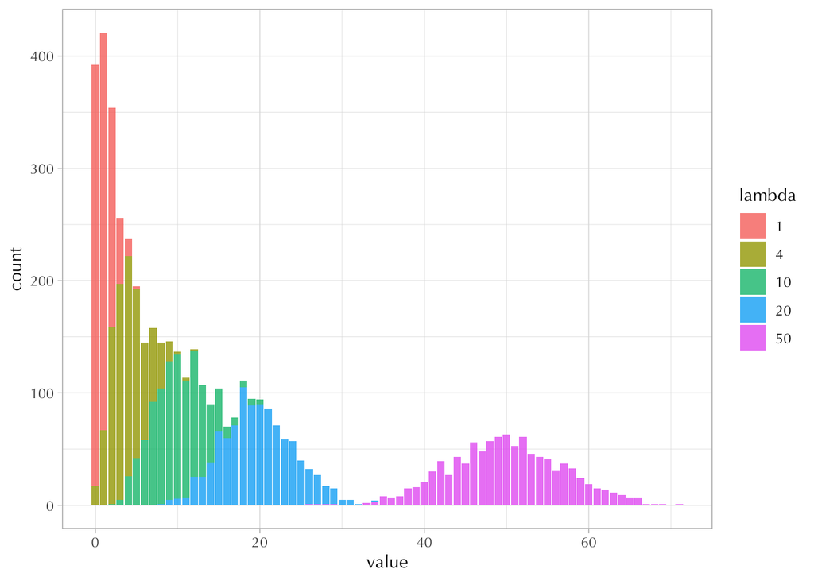

```r
lambda_value <- c(1, 4, 10, 20, 50)
draw_num <- 1000
pois_mat <- matrix(NA, ncol = 2)
for (i in c(1:length(lambda_value))){
  temp <- matrix(NA, nrow = draw_num, ncol = 2)
  temp[,1] <- rep(lambda_value[i], draw_num)
  temp[,2] <- rpois(n = draw_num, lambda = lambda_value[i])
  pois_mat <- rbind(pois_mat, temp)
}

# remove the start value
pois_mat <- pois_mat[c(2:nrow(pois_mat)),]

pois_df <- as.data.frame(pois_mat)
colnames(pois_df) <- c("lambda", "value")

# Plot
ggplot(pois_df |> mutate(lambda = as.factor(lambda)), aes(x = value, group = lambda, fill = lambda)) +
  geom_bar(alpha = 0.8)
```

It seems that when $\lambda$ value is larger and larger, the shape of a poisson distribution is more and more close to a normal distribution with a mean equal to $\lambda$

## 11.2.2 `numtot`

```r
df <- d |>
  mutate(
    sex_new = as.factor(ifelse(sex == 1, "male","female")),
    sex_new = relevel(sex_new, ref = "female"),
    sexornt_new = as.factor(case_when(
      sexornt == 1 ~ "homo",
      sexornt == 2 ~ "bi",
      sexornt == 3 ~ "str"
    )),
    sexornt_new = relevel(sexornt_new, ref = "str"),
    polviews_new = as.factor(case_when(
      polviews <= 3 ~ "liberal",
      polviews == 4 ~ "neutral",
      polviews >= 5 ~ "conservative"
    )),
    polviews_new = relevel(polviews_new, ref = "neutral")
  ) |>
  select(numtot, sex_new, sexornt_new, polviews_new, age, degree, numwomen, nummen) |>
  drop_na() |>
  filter(numwomen <= 989 & nummen <= 989) # Drop NA

# Model
numtot_mod1 <- glm(formula = numtot ~ sex_new + sexornt_new, data = df, family = "poisson")
numtot_mod2 <- glm(formula = numtot ~ sex_new + sexornt_new + age, data = df, family = "poisson")
numtot_mod3 <- glm(formula = numtot ~ sex_new + sexornt_new + age + degree, data = df, family = "poisson")
numtot_mod4 <- glm(formula = numtot ~ sex_new : sexornt_new + age + degree, data = df, family = "poisson")
msummary(list(numtot_mod1, numtot_mod2, numtot_mod3, numtot_mod4), output = "gt") |>
  opt_table_font(font = "Optima")
```

|  | (1) | (2) | (3) | (4) |
| --- | --- | --- | --- | --- |
| (Intercept) | 1.772 | 1.282 | 1.358 | 2.293 |
|  | (0.016) | (0.029) | (0.031) | (0.084) |
| sex_newmale | 1.045 | 1.043 | 1.045 |  |
|  | (0.019) | (0.019) | (0.019) |  |
| sexornt_newbi | 0.362 | 0.454 | 0.467 |  |
|  | (0.048) | (0.048) | (0.048) |  |
| sexornt_newhomo | -0.093 | -0.027 | -0.010 |  |
|  | (0.062) | (0.062) | (0.062) |  |
| age |  | 0.010 | 0.010 | 0.010 |
|  |  | (0.000) | (0.000) | (0.000) |
| degree |  |  | -0.049 | -0.048 |
|  |  |  | (0.007) | (0.007) |
| sex_newfemale × sexornt_newstr |  |  |  | -0.951 |
|  |  |  |  | (0.082) |
| sex_newmale × sexornt_newstr |  |  |  | 0.108 |
|  |  |  |  | (0.081) |
| sex_newfemale × sexornt_newbi |  |  |  | -0.411 |
|  |  |  |  | (0.097) |
| sex_newmale × sexornt_newbi |  |  |  | 0.429 |
|  |  |  |  | (0.118) |
| sex_newfemale × sexornt_newhomo |  |  |  | -0.797 |
|  |  |  |  | (0.125) |
| Num.Obs. | 1217 | 1217 | 1217 | 1217 |
| AIC | 30789.9 | 30371.5 | 30327.0 | 30322.6 |
| BIC | 30810.3 | 30397.1 | 30357.7 | 30363.4 |
| Log.Lik. | -15390.935 | -15180.775 | -15157.514 | -15153.305 |
| F | 993.087 | 855.032 | 694.147 |  |
| RMSE | 37.99 | 37.91 | 37.90 | 37.89 |

The fourth model with interaction term of sex and sex orientation has the lowest AIC, but the third model without interaction term has the lowest BIC.

## 11.2.3 `sibs`

```r
df <- d |>
  mutate(
    f_hs = ifelse(padeg == 0, F, T),
    m_hs = ifelse(madeg == 0, F, T),
    female = ifelse(sex == 2, T, F),
    race_new = as.factor(case_when(
      race == 1 ~ "White",
      race == 2 ~ "Black",
      race == 3 ~ "Other"
    ))
  ) |>
  select(sibs, f_hs, m_hs, female, race_new) |>
  drop_na()
sibs_mod1 <- glm(formula = sibs ~ f_hs + m_hs, data = df, family = "poisson")
sibs_mod2 <- glm(formula = sibs ~ f_hs + m_hs + female, data = df, family = "poisson")
sibs_mod3 <- glm(formula = sibs ~ f_hs + m_hs + female + race_new, data = df, family = "poisson")
msummary(list(sibs_mod1, sibs_mod2, sibs_mod3), output = "gt") |>
  opt_table_font(font = "Optima")
```

|  | (1) | (2) | (3) |
| --- | --- | --- | --- |
| (Intercept) | 1.640 | 1.610 | 1.936 |
|  | (0.023) | (0.028) | (0.041) |
| f_hsTRUE | -0.193 | -0.192 | -0.169 |
|  | (0.035) | (0.035) | (0.035) |
| m_hsTRUE | -0.445 | -0.442 | -0.427 |
|  | (0.035) | (0.035) | (0.035) |
| femaleTRUE |  | 0.050 | 0.049 |
|  |  | (0.027) | (0.027) |
| race_newOther |  |  | -0.265 |
|  |  |  | (0.048) |
| race_newWhite |  |  | -0.437 |
|  |  |  | (0.036) |
| Num.Obs. | 1645 | 1645 | 1645 |
| AIC | 7384.8 | 7383.4 | 7249.5 |
| BIC | 7401.0 | 7405.0 | 7281.9 |
| Log.Lik. | -3689.414 | -3687.700 | -3618.741 |
| F | 226.790 | 152.323 | 121.216 |
| RMSE | 2.55 | 2.55 | 2.49 |

Model 3 has the lowest AIC and BIC.